## Import the required Libraries

```python
from nltk.corpus import stopwords
from sklearn.datasets import fetch_20newsgroups
from sklearn.linear_model import SGDClassifier, LogisticRegression
import numpy as np
from nltk.corpus import reuters
from sklearn.preprocessing import MultiLabelBinarizer
from sklearn.feature_extraction.text import CountVectorizer, TfidfTransformer
from sklearn.pipeline import Pipeline
from sklearn.neighbors import KNeighborsClassifier
from sklearn.naive_bayes import MultinomialNB
import timeit
import matplotlib.pyplot as plt
from nltk.tokenize import RegexpTokenizer
from nltk.stem.porter import PorterStemmer
from gensim import corpora, models
import warnings
warnings.filterwarnings(action='ignore', category=UserWarning, module='gensim')
import gensim
from gensim.models import Phrases
from gensim.corpora import Dictionary
stop_words = set(stopwords.words('english'))
p_stemmer = PorterStemmer()
tokenizer = RegexpTokenizer(r'\w+')
```

```
unable to import 'smart_open.gcs', disabling that module
```

## Reading the given data

```python
import pandas as pd
trials_data = pd.read_csv("us_trial.text", sep="/t,/n", header = None)
trials_data.columns = ['original_text']
print(trials_data)
```

```
                                           original_text
0      A little throwback with my favourite person @ ...
1      glam on @user yesterday for #kcon makeup using...
2      Democracy Plaza in the wake of a stunning outc...
3       Then &amp; Now. VILO @ Walt Disney Magic Kingdom
4                   Who never... @ A Galaxy Far Far Away
...                                                  ...
49995  My #O2otd Love this chain so much and our new ...
49996  Met Santa and Olaf @ the North Pole today @ No...
49997  New York by Night Strideby #HERElocationNYC......
49998  Kisses for the birthday girl! @ Helzberg Diamonds
49999  Dinner with this priceless view!Thank you, S #...

[50000 rows x 1 columns]
```

```python
trials_data['labels'] = pd.read_csv("us_trial.labels", sep="\t", header = None)
```

There are 50,000 records and corresponding labels, let's check the number of unique values in the target variable

## Check the number of unique values in the target variable

```python
trials_data['labels'].unique()
```

```
array([ 0,  7, 11,  2,  1,  8, 13,  9, 16, 19,  4,  6, 14,  5, 10, 15,  3,
       12, 17, 18], dtype=int64)
```

There are 20 unique labels, let's check the value count for each label

```python
trials_data['labels'].value_counts()
```

```
0     10760
1      5279
2      5241
3      2885
4      2517
5      2317
6      2049
7      1894
8      1796
9      1671
10     1544
11     1528
12     1462
14     1377
13     1346
16     1306
18     1286
17     1279
15     1249
19     1214
Name: labels, dtype: int64
```

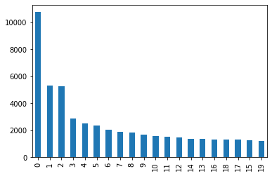

```python
trials_data['labels'].value_counts().plot.bar(x='lab', y='val')
```

### Creating training and test sets

We'll be using 80% of the tweets (for each profile) for training and 20% for testing, i.e. a 80-20 split as mentioned in [this](http://snap.stanford.edu/soma2010/papers/soma2010_12.pdf) paper by Davison et al. Cross validation can and should be done.

```python
from sklearn.model_selection import train_test_split

train_data, test_data, train_labels, test_labels = train_test_split(trials_data['original_text'], trials_data['labels'],
                                                    stratify=trials_data['labels'],
                                                    test_size=0.20)
```

## Function to word_transform (convert into lower case, split and remove stop words)

```python
def word_transform(doc_set, ldamodel, dictionary,no_topics):
    data = []
    # loop through document list
    for i in doc_set:
        doc = ' '.join([word for word in i.split() if word not in stop_words])
        doc = doc.lower()
        doc = doc.split()
        #print(doc_lda)
        doc_prob = [0] * no_topics
        for j in doc:
            if j in stop_words:
                continue
            word_dist = ldamodel.get_document_topics(dictionary.doc2bow(list(j)))#ldamodel[dictionary.doc2bow(list(j))]
            for k in word_dist:
                doc_prob[int(k[0])] = doc_prob[int(k[0])] + float(k[1])
        data.append(doc_prob )
        #print(doc_prob)
    return data
```

## Function to topic_transform (convert into lower case, split and remove stop words)

```python
def topic_transform(doc_set, ldamodel, dictionary,no_topics):
    data = []
    # loop through document list
    for i in doc_set:
        doc = ' '.join([word for word in i.split() if word not in stop_words])
        doc = doc.lower()
        doc_lda = ldamodel[dictionary.doc2bow(tokenizer.tokenize(doc))]
        #print(doc_lda)
        doc_prob = [0] * no_topics
        for j in doc_lda:
            doc_prob[int(j[0])] = float(j[1])
        data.append(doc_prob)
        #print(doc_prob)
    return data
```

## Function to tokenize the document

```python
def tokenize(doc_set):
    # list for tokenized documents in loop
    texts = []
    tokenizer = RegexpTokenizer(r'\w+')
    # loop through document list
    for i in doc_set:
        # clean and tokenize document string
        raw = i.lower()
        tokens = tokenizer.tokenize(raw)

        # remove stop words from tokens
        stopped_tokens = [i for i in tokens if not i in stop_words]

        # stem tokens
        stemmed_tokens = [p_stemmer.stem(i) for i in stopped_tokens]
        # add tokens to list
        texts.append(stemmed_tokens)
    return texts
```

## Code to create corpus from our document

```python
def create_corpus(doc_set):
    texts = tokenize(doc_set)
    # turn our tokenized documents into a id <-> term dictionary
    dictionary = corpora.Dictionary(texts)
    dictionary.filter_extremes(no_below=10, no_above=0.5)
    # convert tokenized documents into a document-term matrix
    corpus = [dictionary.doc2bow(text) for text in texts]
    return dictionary, corpus
```

## Function to load Glove Data

```python
def load_glove_data():
    # read the word to vec file
    GLOVE_6B_100D_PATH = "glove.6B.100d.txt"
    dim = 100
    glove_small = {}
    with open(GLOVE_6B_100D_PATH, "rb") as infile:
        for line in infile:
            parts = line.split()
            try:
                word = parts[0].decode("utf-8")
                x = []
                for i in range(len(parts)-1):
                    x.append(float(parts[i+1].decode("utf-8")))
                glove_small[word] = x
            except:
                print('')
    return glove_small
```

## Function for word2vec Transformation (glove 100d for this use case)

```python
def word2vec_transform(dataset, word2vec, dim):
    trans_data = []
    for doc in dataset:
        words = doc.lower().split()
        w_length = 1
        data = np.zeros(dim)
        for i in range(len(words)):
            if words[i] in word2vec and words[i] not in stop_words:
                data = data + word2vec[words[i]]
                w_length = w_length + 1
        data = data / float(w_length)
        trans_data.append(data)
    return trans_data
```

## Try different models on Count Vectorized Train data

```python
def tf_classify(train_docs, train_labels, test_docs, test_labels):
    text_clf = Pipeline([('vect', CountVectorizer()), ('clf',LogisticRegression()) ])
    text_clf.fit(train_docs, train_labels)
    predicted = text_clf.predict(test_docs)
    print("tf_LogisticReg    " + str(100 * np.mean(predicted == test_labels)))

    text_clf = Pipeline([('vect', CountVectorizer()), ('clf',MultinomialNB()) ])
    text_clf.fit(train_docs, train_labels)
    predicted = text_clf.predict(test_docs)
    print("tf_MultiNaiveBayes    " + str(100 * np.mean(predicted == test_labels)))

    text_clf = Pipeline([('vect', CountVectorizer()), ('clf',KNeighborsClassifier(n_neighbors=3)) ])
    text_clf.fit(train_docs, train_labels)
    predicted = text_clf.predict(test_docs)
    print("tf_KNN    " + str(100 * np.mean(predicted == test_labels)))

    text_clf = Pipeline([('vect', CountVectorizer()), ('clf', SGDClassifier(random_state=42, tol=.001)), ])
    text_clf.fit(train_docs, train_labels)
    predicted = text_clf.predict(test_docs)
    print("tf_sgd    " + str(100 * np.mean(predicted == test_labels)))
```

## Try different models on TFIDF Train data

```python
def tf_idf_classify(train_docs, train_labels, test_docs, test_labels):
    text_clf = Pipeline([('vect', CountVectorizer()), ('tfidf', TfidfTransformer()), ('clf',LogisticRegression()) ])
    text_clf.fit(train_docs, train_labels)
    predicted = text_clf.predict(test_docs)
    print("tf_idf_LogisticReg    " + str(100 * np.mean(predicted == test_labels)) )

    text_clf = Pipeline([('vect', CountVectorizer()), ('tfidf', TfidfTransformer()), ('clf',MultinomialNB()) ])
    text_clf.fit(train_docs, train_labels)
    predicted = text_clf.predict(test_docs)
    print("tf_idf_MultiNaiveBayes    " + str(100 * np.mean(predicted == test_labels)) )

    text_clf = Pipeline([('vect', CountVectorizer()), ('tfidf', TfidfTransformer()), ('clf',KNeighborsClassifier(n_neighbors=3)) ])
    text_clf.fit(train_docs, train_labels)
    predicted = text_clf.predict(test_docs)
    print("tf_idf_KNN    " + str(100 * np.mean(predicted == test_labels)) )

    text_clf = Pipeline([('vect', CountVectorizer()), ('tfidf', TfidfTransformer()), ('clf', SGDClassifier(random_state=42, tol=.001)), ])
    text_clf.fit(train_docs, train_labels)
    predicted = text_clf.predict(test_docs)
    print("tf_idf_sgd    " + str(100 * np.mean(predicted == test_labels))  )
```

## Try different models on Glove Transformed Train data

```python
def word2vec_classify(train_docs, train_labels, test_docs, test_labels):
    word2vec = load_glove_data()
    train_docs = word2vec_transform(train_docs, word2vec, 100)
    test_docs = word2vec_transform(test_docs, word2vec, 100)

    text_clf = LogisticRegression()
    text_clf.fit(train_docs, train_labels)
    predicted = text_clf.predict(test_docs)
    print("word2vec_tf_LogisticReg    " + str(100 * np.mean(predicted == test_labels)))

    #text_clf = MultinomialNB()
    #text_clf.fit(train_docs, train_labels)
    #predicted = text_clf.predict(test_docs)
    #print("word2vec_tf_MultiNaiveBayes    " + str(100 * np.mean(predicted == test_labels)))

    text_clf = KNeighborsClassifier(n_neighbors=3)
    text_clf.fit(train_docs, train_labels)
    predicted = text_clf.predict(test_docs)
    print("word2vec_KNN    " + str(100 * np.mean(predicted == test_labels)))

    sgd = SGDClassifier(random_state=420, tol=.001)#MultinomialNB()
    sgd.fit(train_docs, train_labels)
    predicted = sgd.predict(test_docs)
    print("word2vec_sgd    " + str(100 * np.mean(predicted == test_labels))  )
```

## Try different models on Glove Transformed and LDA

```python
def LDA_classify(train_docs, train_labels, test_docs, test_labels):
    text_clf = LogisticRegression()
    text_clf.fit(train_docs, train_labels)
    predicted = text_clf.predict(test_docs)
    Log_accu = 100 * np.mean(predicted == test_labels)
    print("LDA_LogisticReg " + str(Log_accu))

    #text_clf = MultinomialNB()
    #text_clf.fit(train_docs, train_labels)
    #predicted = text_clf.predict(test_docs)
    #NB_accu = 100 * np.mean(predicted == test_labels)
    #print("LDA_MultiNB     " + NB_accu)

    text_clf = KNeighborsClassifier(n_neighbors=3)
    text_clf.fit(train_docs, train_labels)
    predicted = text_clf.predict(test_docs)
    KNN_accu = 100 * np.mean(predicted == test_labels)
    print("LDA_KNN     " + str(KNN_accu))

    sgd = SGDClassifier(random_state=420, tol=.001)#MultinomialNB()
    sgd.fit(train_docs, train_labels)
    predicted = sgd.predict(test_docs)
    sgd_accu = 100 * np.mean(predicted == test_labels)
    print("LDA_sgd     " + str(sgd_accu))
    return Log_accu,KNN_accu,sgd_accu
```

## Build your models on train data and test and test data

```python
tf_classify(train_data, train_labels, test_data, test_labels)
tf_idf_classify(train_data, train_labels, test_data, test_labels)
word2vec_classify(train_data, train_labels, test_data, test_labels)
```

```
tf_LogisticReg    28.98
tf_MultiNaiveBayes    26.83
tf_KNN    18.85
tf_sgd    28.09
```

```
tf_idf_LogisticReg    30.89
tf_idf_MultiNaiveBayes    23.14
tf_idf_KNN    20.1
tf_idf_sgd    28.050000000000004
```

```
word2vec_tf_LogisticReg    27.26
word2vec_KNN    20.11
word2vec_sgd    16.57
```

```python
no_topics = [5, 10, 15, 20, 25, 30, 35, 40]
dictionary, corpus = create_corpus(str(train_data) + str(test_data))
time = np.zeros(len(no_topics))

topics_accu_Log = np.zeros(len(no_topics))
#topics_accu_MNB = np.zeros(len(no_topics))
topics_accu_KNN = np.zeros(len(no_topics))
topics_accu_sgd = np.zeros(len(no_topics))

words_accu_Log = np.zeros(len(no_topics))
#words_accu_MNB = np.zeros(len(no_topics))
words_accu_KNN = np.zeros(len(no_topics))
words_accu_sgd = np.zeros(len(no_topics))
```

```python
for i in range(len(no_topics)):
    # train LDA model
    start = timeit.default_timer()
    ldamodel = gensim.models.ldamodel.LdaModel(corpus, num_topics=no_topics[i], id2word = dictionary, passes=30)
    end = timeit.default_timer()
    time[i] = end - start
    print(time[i])

    # get data represented as a distribution over the topics
    test_docs = topic_transform(test_data, ldamodel, dictionary,no_topics[i])
    train_docs = topic_transform(train_data, ldamodel, dictionary,no_topics[i])
    topics_accu_Log[i], topics_accu_KNN[i], topics_accu_sgd[i] =  LDA_classify(train_docs, train_labels, test_docs, test_labels)

    test_docs = word_transform(test_data, ldamodel, dictionary,no_topics[i])
    train_docs = word_transform(train_data, ldamodel, dictionary,no_topics[i])
    words_accu_Log[i], words_accu_KNN[i], words_accu_sgd[i] =  LDA_classify(train_docs, train_labels, test_docs, test_labels)
```

```
24.88611739999999
LDA_LogisticReg 21.52
LDA_KNN     21.02
LDA_sgd     21.060000000000002
```

```
LDA_LogisticReg 21.51
LDA_KNN     15.329999999999998
LDA_sgd     5.7299999999999995
24.13413509999998
```

```
LDA_LogisticReg 21.52
LDA_KNN     10.79
LDA_sgd     3.1199999999999997
```

```
LDA_LogisticReg 21.37
LDA_KNN     15.229999999999999
LDA_sgd     21.54
26.06492359999993
```

```
LDA_LogisticReg 21.52
LDA_KNN     21.08
LDA_sgd     2.6
```

```
LDA_LogisticReg 21.5
LDA_KNN     15.45
LDA_sgd     9.92
29.158257100000128
```

```
LDA_LogisticReg 21.52
LDA_KNN     21.15
LDA_sgd     2.8000000000000003
```

```
LDA_LogisticReg 21.34
LDA_KNN     15.39
LDA_sgd     8.83
27.872921099999985
```

```
LDA_LogisticReg 21.52
LDA_KNN     20.87
LDA_sgd     2.83
```

```
LDA_LogisticReg 21.43
LDA_KNN     15.129999999999999
LDA_sgd     14.66
30.935923800000182
```

```
LDA_LogisticReg 21.52
LDA_KNN     20.830000000000002
LDA_sgd     2.68
```

```
LDA_LogisticReg 21.37
LDA_KNN     15.57
LDA_sgd     13.87
33.42821779999986
```

```
LDA_LogisticReg 21.529999999999998
LDA_KNN     20.95
LDA_sgd     2.6599999999999997
```

```
LDA_LogisticReg 21.4
LDA_KNN     15.76
LDA_sgd     14.01
8.828369100000145
```

```
LDA_LogisticReg 21.529999999999998
LDA_KNN     4.12
LDA_sgd     2.77
```

```
LDA_LogisticReg 21.42
LDA_KNN     15.310000000000002
LDA_sgd     11.27
```

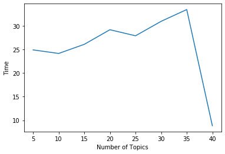

[figure not shown]

```python
plt.figure(1)
plt.plot(no_topics, time)
plt.xlabel('Number of Topics')
plt.ylabel('Time')

plt.figure(2)
plt.plot(no_topics, topics_accu_KNN)
plt.plot(no_topics, topics_accu_sgd)
plt.plot(no_topics, words_accu_KNN)
plt.plot(no_topics, words_accu_sgd)
plt.xlabel('Number of Topics')
plt.ylabel('Accuracy')
plt.legend(['Logistic_topics','KNN_topics', 'sgd_topics', 'Logistic_words', 'KNN_words', 'sgd_words'], loc='upper left')
plt.show()
```

Let us build these 3 ML models on TF, TFIDF and word2vec train data

```python
from keras.layers import  Dropout, Dense
from keras.models import Sequential

import numpy as np
from sklearn import metrics
```

```python
def ANN_Model(shape, nClasses, dropout=0.5):
    """
    ANN_Model(shape, nClasses,dropout)
    Build Deep neural networks Model for text classification
    Shape is input feature space
    nClasses is number of classes
    """
    model = Sequential()
    node = 64 # number of nodes
    nLayers = 4 # number of  hidden layer

    model.add(Dense(node,input_dim=shape,activation='relu'))
    model.add(Dropout(dropout))
    for i in range(0,nLayers):
        model.add(Dense(node,input_dim=node,activation='relu'))
        model.add(Dropout(dropout))
    model.add(Dense(nClasses, activation='softmax'))

    model.compile(loss='sparse_categorical_crossentropy',
                  optimizer='adam',
                  metrics=['accuracy'])

    return model
```

```python
from tensorflow.keras.utils import to_categorical
from keras.utils import np_utils

cv = CountVectorizer(max_features=30000)

X_train = cv.fit_transform(train_data)
X_test = cv.transform(test_data)


y_train = to_categorical(train_labels, num_classes=20)
y_test = to_categorical(test_labels, num_classes=20)

print("Shape of y_train:", y_train.shape)
print("One value of y_train:", y_train[0])

# convert integers to dummy variables (i.e. one hot encoded)
#y_train_dumm = np_utils.to_categorical(y_train)
```

```
Shape of y_train: (40000, 20)
One value of y_train: [0. 0. 0. 0. 0. 0. 0. 0. 0. 0. 0. 1. 0. 0. 0. 0. 0. 0. 0. 0.]
```

```python
from tensorflow.keras.models import Sequential
from tensorflow.keras.layers import Flatten, Dense

model = Sequential()
#model.add(Flatten())
model.add(Dense(128, activation="relu"))

model.add(Dense(20, activation='softmax'))

model.compile(loss='sparse_categorical_crossentropy', optimizer='adam', metrics=['accuracy'])
model.fit(X_train,y_train, epochs=20)
```

[output not shown]

[output cut: 52 more lines]

[output not shown]

```python
ann_clf = ANN_Model(30000,y_train.shape[1])
#ann_clf.summary()
ann_clf.fit(X_train, y_train, epochs=20, batch_size = 32)
```

[output not shown]

```python
ann_clf = Pipeline([('vect', CountVectorizer(max_features=30000)), ('clf',ANN_Model(30000, 20)) ])
ann_clf.fit(train_data, train_labels)
```

```
Pipeline(memory=None,
         steps=[('vect',
                 CountVectorizer(analyzer='word', binary=False,
                                 decode_error='strict',
                                 dtype=<class 'numpy.int64'>, encoding='utf-8',
                                 input='content', lowercase=True, max_df=1.0,
                                 max_features=30000, min_df=1,
                                 ngram_range=(1, 1), preprocessor=None,
                                 stop_words=None, strip_accents=None,
                                 token_pattern='(?u)\\b\\w\\w+\\b',
                                 tokenizer=None, vocabulary=None)),
                ('clf',
                 <keras.engine.sequential.Sequential object at 0x00000195C649FD88>)],
         verbose=False)
```

```python
predicted = ann_clf.predict(test_data)
print("tf_ANN    " + str(100 * np.mean(predicted == test_labels)))
```

```
tf_ANN    0.0
```

```python
ann_clf = Pipeline([('vect', CountVectorizer(max_features=30000)), ('tfidf', TfidfTransformer()), ('clf',ANN_Model(30000, 20)) ])
ann_clf.fit(train_data, train_labels)
predicted = ann_clf.predict(test_data)
print("tfidf_ANN    " + str(100 * np.mean(predicted == test_labels)))
```

[output not shown]